# Laboratory 8 - SMDS

N Torelli, G Di Credico, V Gioia

22/12/2022

# Spline functions

Splines are functions defined as piecewise polynomials of fixed degree. The points of connections of the polynomials are called knots. The idea is that, between two knots, the function $f(x)$ is a a said polynomial and such polynomials meets at the knots, with further constraints to achieve regularity constraints. For instance, given $K$ knots $\zeta_1, \ldots, \zeta_K$, a cubic (degree = 3) regression spline is expressed as
$$f(x;\boldsymbol \beta)= \beta_0 +\beta_1 x + \beta_2 x^2 + \beta_3 x^3 + \sum_{k=1}^{K} \beta_{k+3} (x-\zeta_k)^3_{+}$$
with $(x-\zeta_k)^3_{+}=max(0, (x-\zeta_k)^3)$. We call spline basis functions the $h_j(x) = x^{j-1}$, $j=1, \ldots, 4$ and $h_j(x) = (x-\zeta_j)^3_{+}$, $j=1, \ldots, k$. However, different basis expansions can be used to define a spline function and in general
$$f(x;\boldsymbol \beta)= \sum_{k=0}^{K+d} \beta_{k} h_k(x)$$

We will adopt the B-spline which are built by means of the Cox–de Boor recursion formula

We use a naive application on `Boston` dataset available in the `MASS` package to compare the use of polynomials and splines. The dataset collects information on housing values in suburbs of Boston and in particular we are going to model the continuous variable `medv` (median value of owner-occupied homes in $1000s) using a simple linear model including the continuous variable `lstat` (lower status of the population) as a predictor.

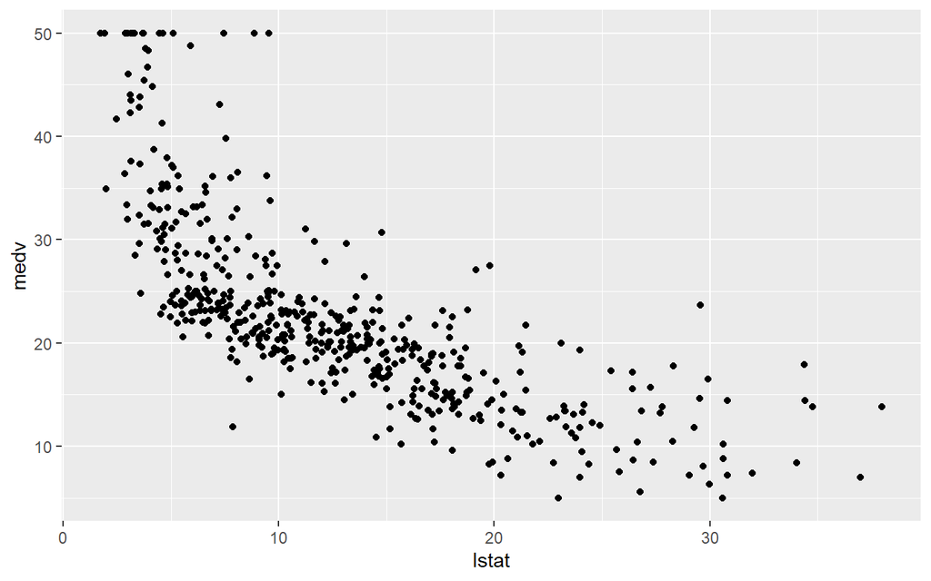

```r
library(splines)
library(ggplot2)
library(MASS)
# Load the dataset Boston in the MASS package
data(Boston)

# Scatterplot of medv (y) and lstat (x) by using ggplot()
ggplot(Boston, aes(lstat, medv))+
 geom_point()
```

As first step, we fit a linear model and then we analyse the residuals.

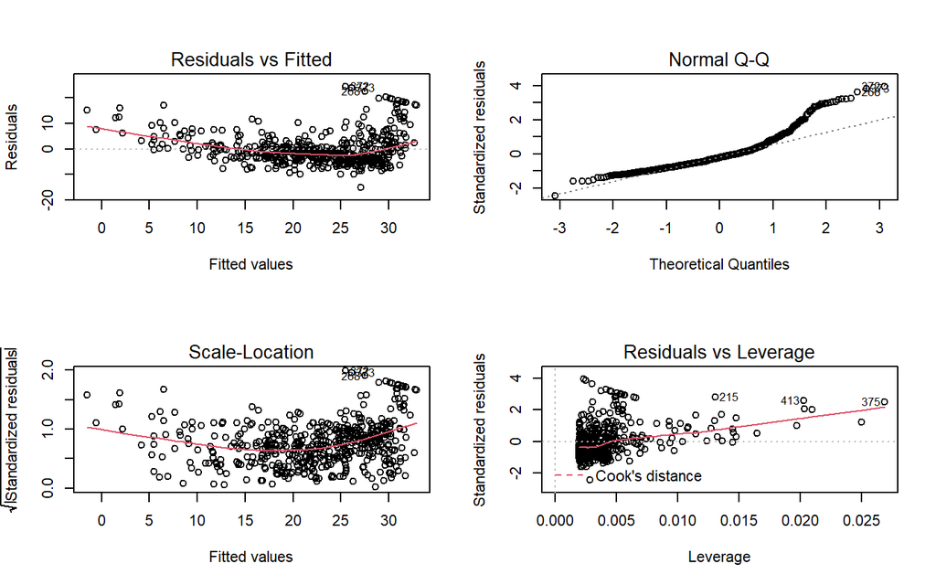

```r
# Fit a simple linear model
fit <- lm(medv ~ lstat, data = Boston)

# Analysis of the residual
par(mfrow=c(2,2))
plot(fit)
```

Then, we consider a quadratic term for lstat.

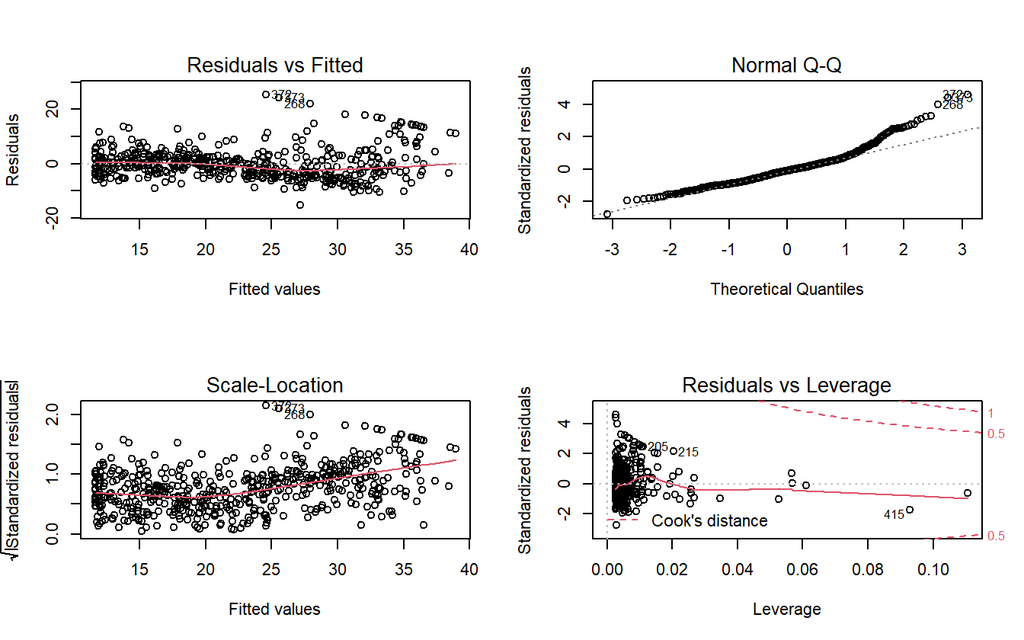

```r
# Fit a linear model considering a quadratic term for lstat
# Two way to do this:
fit.poly2 <- lm(medv ~ lstat + I(lstat^2), data = Boston)
fit.poly2 <- lm(medv ~ poly(lstat, 2, raw = TRUE), data = Boston) #if false orthogonal polynomial


# Analysis of the residual
par(mfrow=c(2,2))
plot(fit.poly2)
```

Then, we consider a a polynomial of degree 5 for lstat.

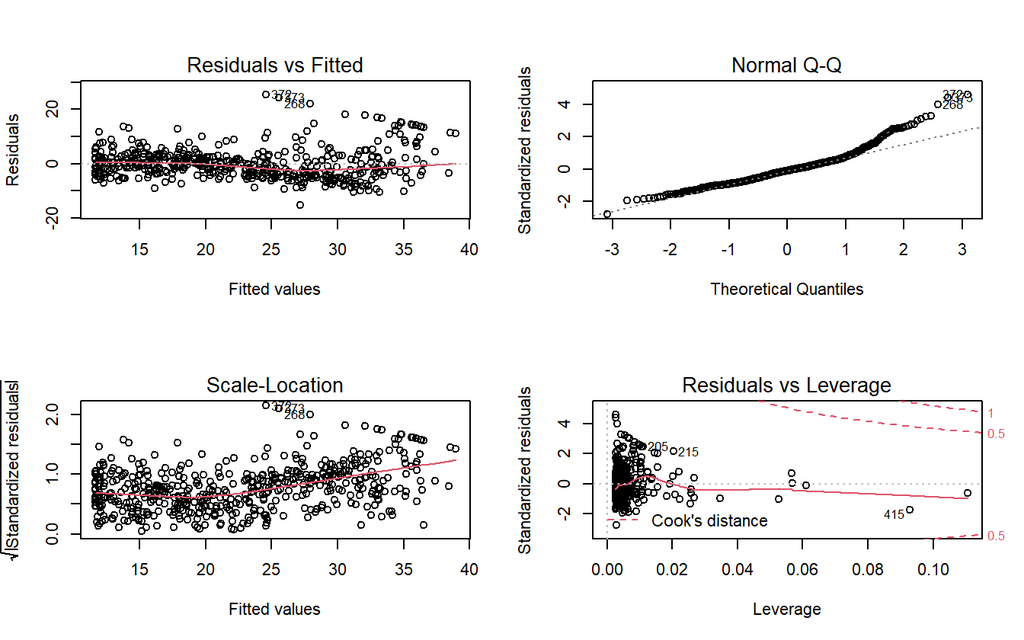

```r
# Fit a linear model considering a polynomial of degree 5 for lstat
fit.poly5 <- lm(medv ~ poly(lstat, 5, raw = TRUE), data = Boston)
# Analysis of the residual
par(mfrow=c(2,2))
plot(fit.poly2)
```

Compare our fitted curve.

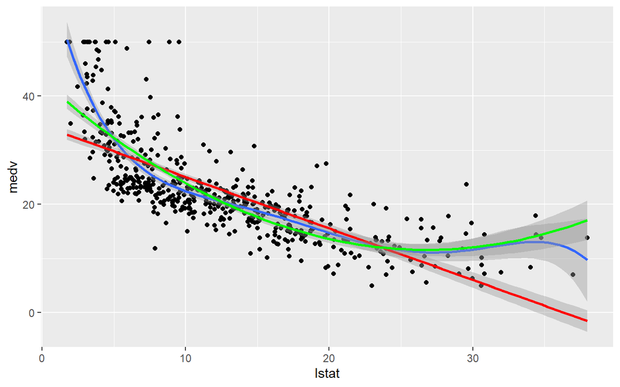

```r
# Plot the fitted curve by using ggplot
ggplot(Boston, aes(lstat, medv)) +
 geom_point()+
 stat_smooth(method = lm, formula = y ~ poly(x, 5, raw = TRUE))+
 stat_smooth(method = lm, formula = y ~ x, col = "red") +
 stat_smooth(method = lm, formula = y ~ poly(x, 2, raw = TRUE), col = "green")
```

Now we consider the cubic regression spline, namely we consider B-splines by means of **bs()**. We fix the (internal) knots at first, second and third quartile.

```r
# Set the knots
knots <- quantile(Boston$lstat)[2:4]
# Fit the models considering the cubic regression spline (default)
fit.spline <- lm(medv ~ bs(lstat, knots=knots), data=Boston)

summary(fit.spline)
```

```
##
## Call:
## lm(formula = medv ~ bs(lstat, knots = knots), data = Boston)
##
## Residuals:
##      Min       1Q   Median       3Q      Max
## -13.8071  -3.1502  -0.7389   2.1076  26.9529
##
## Coefficients:
##                           Estimate Std. Error t value Pr(>|t|)
## (Intercept)                 50.628      2.582  19.608  < 2e-16 ***
## bs(lstat, knots = knots)1  -13.682      3.886  -3.521  0.00047 ***
## bs(lstat, knots = knots)2  -26.684      2.449 -10.894  < 2e-16 ***
## bs(lstat, knots = knots)3  -28.416      2.917  -9.743  < 2e-16 ***
## bs(lstat, knots = knots)4  -40.092      3.050 -13.144  < 2e-16 ***
## bs(lstat, knots = knots)5  -39.718      4.212  -9.431  < 2e-16 ***
## bs(lstat, knots = knots)6  -38.484      4.134  -9.308  < 2e-16 ***
## ---
## Signif. codes:  0 '***' 0.001 '**' 0.01 '*' 0.05 '.' 0.1 ' ' 1
##
## Residual standard error: 5.206 on 499 degrees of freedom
## Multiple R-squared:  0.6833, Adjusted R-squared:  0.6795
## F-statistic: 179.5 on 6 and 499 DF,  p-value: < 2.2e-16
```

```r
# Similar results could be obtain by specifing the degrees of freedom
# equal to 6 as an alternative to the specification of the knots
fit.spline <- lm(medv ~ bs(lstat, df = 6), data=Boston)

summary(fit.spline)
```

```
##
## Call:
## lm(formula = medv ~ bs(lstat, df = 6), data = Boston)
##
## Residuals:
##      Min       1Q   Median       3Q      Max
## -13.8071  -3.1502  -0.7389   2.1076  26.9529
##
## Coefficients:
##                    Estimate Std. Error t value Pr(>|t|)
## (Intercept)          50.628      2.582  19.608  < 2e-16 ***
## bs(lstat, df = 6)1  -13.682      3.886  -3.521  0.00047 ***
## bs(lstat, df = 6)2  -26.684      2.449 -10.894  < 2e-16 ***
## bs(lstat, df = 6)3  -28.416      2.917  -9.743  < 2e-16 ***
## bs(lstat, df = 6)4  -40.092      3.050 -13.144  < 2e-16 ***
## bs(lstat, df = 6)5  -39.718      4.212  -9.431  < 2e-16 ***
## bs(lstat, df = 6)6  -38.484      4.134  -9.308  < 2e-16 ***
## ---
## Signif. codes:  0 '***' 0.001 '**' 0.01 '*' 0.05 '.' 0.1 ' ' 1
##
## Residual standard error: 5.206 on 499 degrees of freedom
## Multiple R-squared:  0.6833, Adjusted R-squared:  0.6795
## F-statistic: 179.5 on 6 and 499 DF,  p-value: < 2.2e-16
```

A graphical comparison is useful

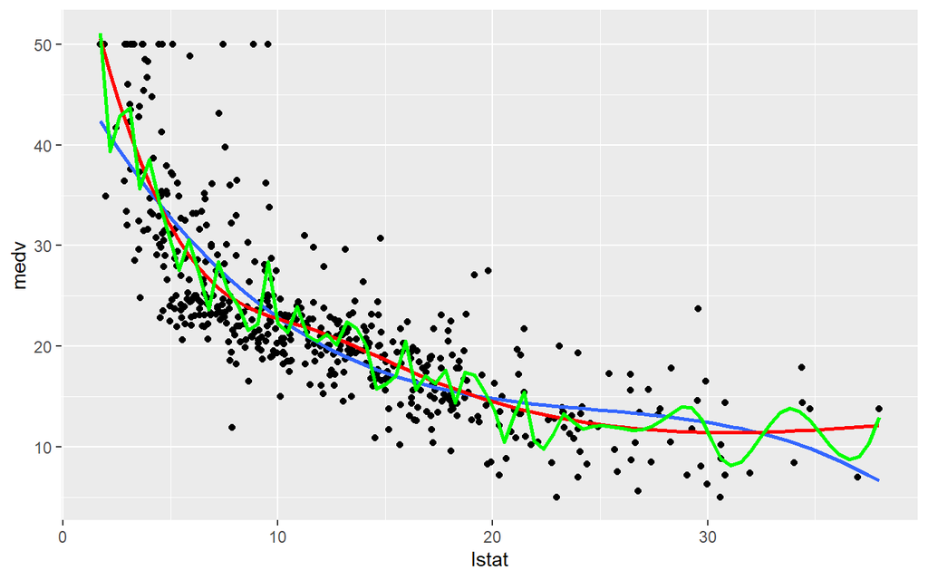

```r
# Plot the fitted lines comparing:
# model 1: polynomial of degree = 3 (BLUE)
# model 2: cubic B-splines with df = 6 (RED)
# model 3: cubic B-splines with df = 100 (GREEN)
ggplot(Boston, aes(lstat, medv)) +
 geom_point()+
 stat_smooth(method = lm, formula = y ~ poly(x, 3, raw = TRUE) , se = FALSE)+
 stat_smooth(method = lm, formula = y ~ bs(x, df = 6), col = "red", se = FALSE) +
 stat_smooth(method = lm, formula = y ~ bs(x, df = 100), col = "green", se = FALSE )
```

We can analyse the AIC

```r
c(AIC(fit.poly2),AIC(fit.spline), AIC(lm(medv ~ bs(lstat, df = 100), data=Boston)))
```

```
## [1] 3170.516 3114.610 3204.101
```

The next plot shows a comparison of 3 spline functions with 1 knot on the median of the predictor and different spline degrees.

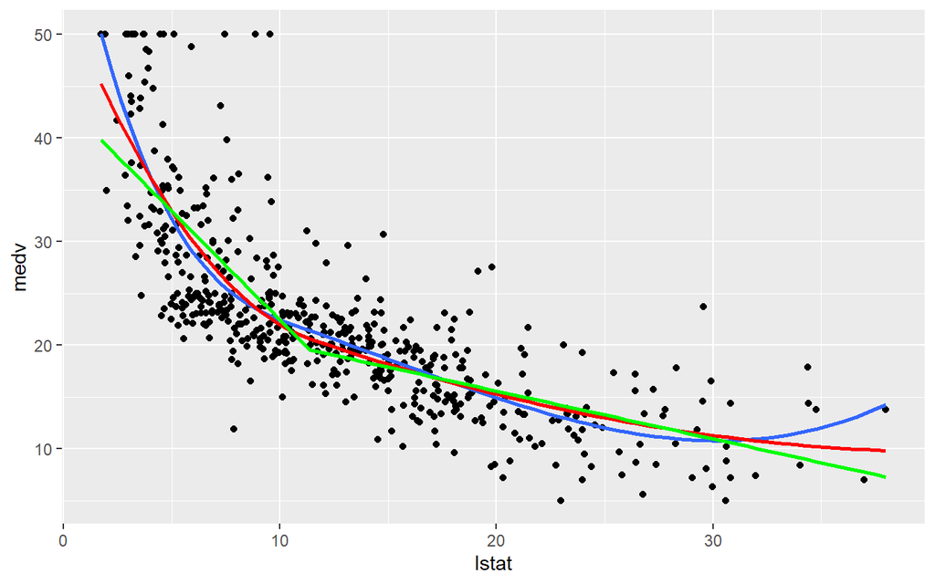

```r
# Plot the fitted lines comparing three different spcification of
# spline degrees (consider one knot on the median):
# model 1: cubic B-splines (BLUE)
# model 2: quadratic B-splines (RED)
# model 3: linear B-splines (GREEN)
knot <- knots[2]
# Equivalently
# knot <- median(Boston$lstat)
ggplot(Boston, aes(lstat, medv)) +
 geom_point()+
 stat_smooth(method = lm, formula = y ~ bs(x, knots = knot), se = FALSE)+
 stat_smooth(method = lm, formula = y ~ bs(x, knots = knot, degree = 2), col = "red", se = FALSE) +
 stat_smooth(method = lm, formula = y ~ bs(x, knots = knot, degree = 1), col = "green", se = FALSE )
```

# Generalized additive models (GAM)

A generalized additive model (GAM) is a generalized linear model (GLM) in which the linear predictor is given by a user specified sum of smooth functions of the covariates plus a conventional parametric component of the linear predictor. Given $\mu_i=E[Y_i]$, a simple example is:

$$\log(\mu_i)= \beta_0+\sum_{j=1}^{p}s_j(x_{ij}), \ i=1,\ldots,n,$$
where the dependent variable $Y_{i} \sim \mathsf{Gamma}(\mu_i, \phi)$ and $s_j$ are smooth functions of covariates $x_j$. GAM models imply the following **likelihood penalization**

$$l(\boldsymbol{\beta}, \boldsymbol{s})-\lambda R(\boldsymbol{s}),$$

where $R(\boldsymbol{s})$ is a measure of roughness.

- if $\lambda \rightarrow \infty \Rightarrow$ **maximal smoothness**. The fitted curve $s(\cdot)$ is a straight line. The *effective number of parameters* associated to the predictor $x_j$ is 1. No need for a smooth function.
- if $\lambda \rightarrow 0\Rightarrow$ **no smoothness**. No penalty is considered and the *effective number of parameters* associated to the predictor $x_j$ is greater than 1.

## Trees dataset

As an example, consider the simple dataset `trees`, where we have measurements of the girth, height and volume of timber in 31 felled black cherry trees. Note that girth is the diameter of the tree (in inches) measured at 4 ft 6 in above the ground. First of all, we use the `pairs` plot (or `chart.Correlation`) for checking possible correlations between the three variables.

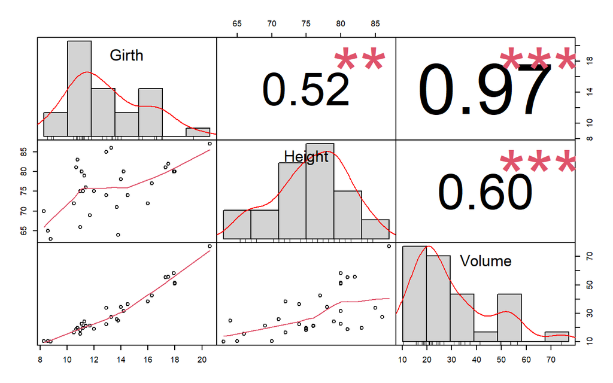

```r
library(mgcv)
library(PerformanceAnalytics)
# Consider the tree dataset
data(trees)
# Look the data
chart.Correlation(trees)
```

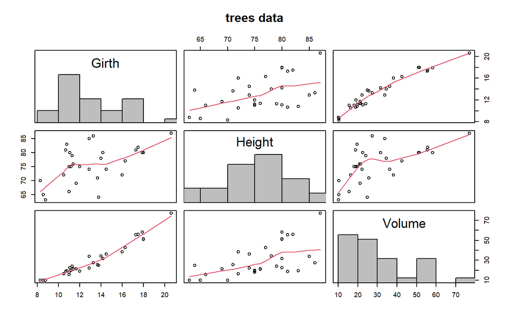

```r
# Otherwise by using pairs
# pairs(trees)
# pairs(trees, panel = panel.smooth)

# Customize the diagonal panel (you can also customize the upper and diagonal panel)
panel.hist <- function(x, ...){
    usr <- par("usr")
    on.exit(par(usr))
    par(usr = c(usr[1:2], 0, 1.5) )
    h <- hist(x, plot = FALSE)
    breaks <- h$breaks
    nB <- length(breaks)
    y <- h$counts
    y <- y/max(y)
    rect(breaks[-nB], 0, breaks[-1], y, col = "grey", ...)
}

pairs(trees, panel = panel.smooth, main = "trees data",diag.panel = panel.hist)
```

### The model

In order to give a general idea about the GAM flexibility, we may start with one predictor. We could fit a simple Generalized Linear Model (GLM), and a GAM model $Y_{i} \sim \mathsf{Gamma}(\mu_i, \phi)$, such that:

$$\begin{align*}
\log(\mu_i)= & \beta_0+\beta_1 \mathsf{Height}_i\\
\log(\mu_i)= & \beta_0+ s_1(\mathsf{Height}_i),
\end{align*}$$

for $i=1,\ldots,n$. The question we pose is whether the GLM structure is good enough for fitting these data. We could start by printing the output of the GAM model; then, we may plot the predicted values for both the models.

```r
# Compare a GLM with a GAM considering a single predictor(Height)
# and the outcome (Volume)  distributed according a Gamma
glm.1 <- glm(Volume ~ Height, data = trees,
             family = Gamma(link = "log"))
gam.1 <- gam(Volume ~ s(Height), data = trees,
             family = Gamma(link = "log"))

# Look the summary
summary(glm.1)
```

```
##
## Call:
## glm(formula = Volume ~ Height, family = Gamma(link = "log"),
##     data = trees)
##
## Deviance Residuals:
##     Min       1Q   Median       3Q      Max
## -0.6719  -0.3199  -0.1358   0.3714   0.5801
##
## Coefficients:
##             Estimate Std. Error t value Pr(>|t|)
## (Intercept) -0.85467    0.88028  -0.971     0.34
## Height       0.05532    0.01154   4.792 4.52e-05 ***
## ---
## Signif. codes:  0 '***' 0.001 '**' 0.01 '*' 0.05 '.' 0.1 ' ' 1
##
## (Dispersion parameter for Gamma family taken to be 0.1622999)
##
##     Null deviance: 8.3172  on 30  degrees of freedom
## Residual deviance: 4.7723  on 29  degrees of freedom
## AIC: 239.67
##
## Number of Fisher Scoring iterations: 4
```

```r
summary(gam.1)
```

```
##
## Family: Gamma
## Link function: log
##
## Formula:
## Volume ~ s(Height)
##
## Parametric coefficients:
##             Estimate Std. Error t value Pr(>|t|)
## (Intercept)  3.34970    0.07236   46.29   <2e-16 ***
## ---
## Signif. codes:  0 '***' 0.001 '**' 0.01 '*' 0.05 '.' 0.1 ' ' 1
##
## Approximate significance of smooth terms:
##           edf Ref.df     F  p-value
## s(Height)   1      1 22.97 4.56e-05 ***
## ---
## Signif. codes:  0 '***' 0.001 '**' 0.01 '*' 0.05 '.' 0.1 ' ' 1
##
## R-sq.(adj) =  0.348   Deviance explained = 42.6%
## GCV = 0.17591  Scale est. = 0.1623    n = 31
```

```r
# Look at the coefficient of gam.1
coef(gam.1)
```

```
##   (Intercept)   s(Height).1   s(Height).2   s(Height).3   s(Height).4
##  3.349704e+00 -1.356217e-07  2.472441e-09 -1.396796e-09 -6.612916e-08
##   s(Height).5   s(Height).6   s(Height).7   s(Height).8   s(Height).9
## -1.861406e-08 -1.725038e-08  8.662929e-09 -8.462102e-08  3.467615e-01
```

```r
# Look at the smoothing parameter
gam.1$sp
```

```
## s(Height)
##  313609.2
```

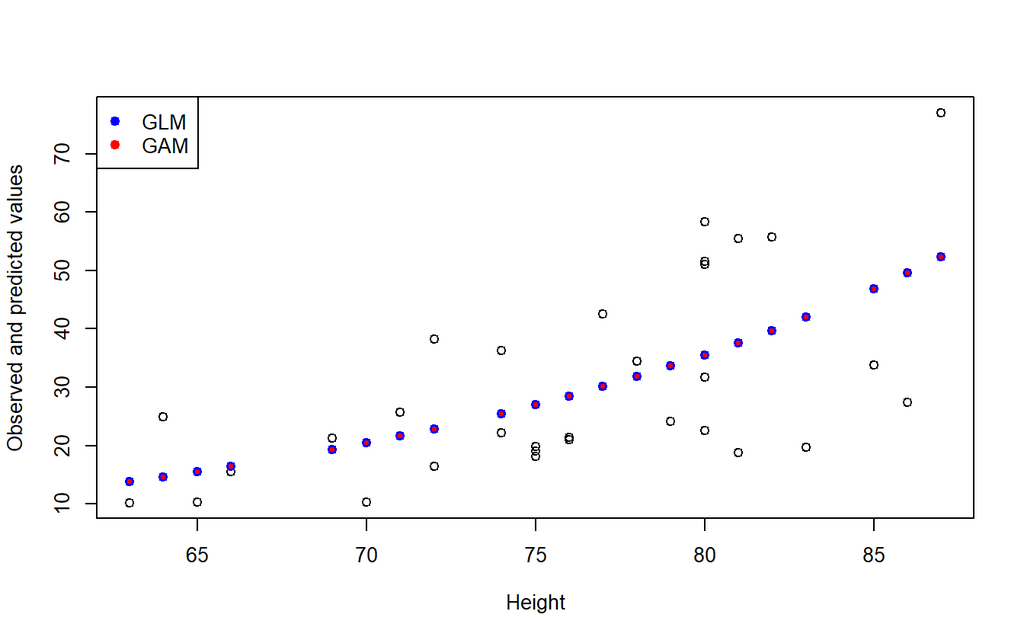

```r
# Plot the predicted values for both models
par(mfrow=c(1,1))
with(trees, plot(Height, Volume, xlab = "Height", ylab = "Observed and predicted values"))
points(trees$Height, glm.1$fitted.values, pch=19, col="blue")
points(trees$Height, gam.1$fitted.values, pch=19, col="red", cex=0.5)
legend("topleft", c("GLM", "GAM"), pch = 19, col = c("blue", "red"))
```

Diagnostic plot involve the representation of the smooth function and the partial residuals defined as:
$$\hat\epsilon^{part}_{ij}=\hat s_j(x_{ij})+\hat\epsilon_i^{P}$$
where $\hat\epsilon^{P}$ are the Pearson residuals of the model. Looking at this plot we are interested in noticing non linearity or wiggle behavior of the smooth function and if the partial residuals are evenly distributed around the function.

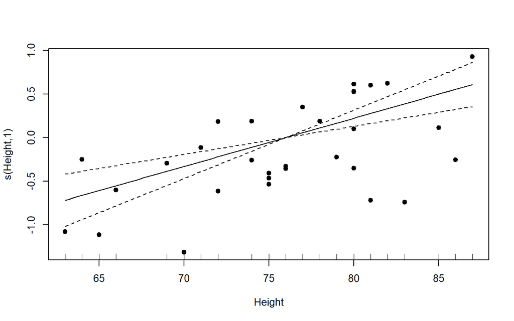

```r
# Diagnostic plot: represents the smooth function and the partial residuals
plot(gam.1,residuals=TRUE,pch=19)
```

```r
# The points represented are
pr_data<-cbind(trees$Height,gam.1$residuals +
               gam(Volume ~ s(Height), data = trees,
                   family = Gamma(link = "log"),
                   fit=FALSE)$X[,2:10] %*%coef(gam.1)[2:10])
#plot(pr_data[,1],pr_data[,2])
```

By the joint analysis of the summary output—look at the value `edf=1`—the prediction plots and the final plot displaying $s(\mathsf{Height})$ versus $\mathsf{Height}$, we may conclude that this simple single predictor framework may be well explained by a GLM approach.

### Adding another predictor

Consider now to add the predictor $\mathsf{Girth}$, and take the same model as before, $Y_{i}=\mathsf{Volume}_i\sim \mathsf{Gamma}(\mu_i, \phi)$, then:

$$\log(\mu_i)=s_1(\mathsf{Height}_i)+s_2(\mathsf{Girth}_i).$$
Analogously as before, we fit the GLM and the GAM model. We plot together the fitted values and we separately analyze the smooth terms $s_1(\mathsf{Height})$ and $s_2(\mathsf{Girth})$.

```r
# Adding another predictor to the model (compare GLM with GAM)
glm.2 <- glm(Volume ~ Height + Girth, data = trees,
             family = Gamma(link = "log"))
gam.2 <- gam(Volume ~ s(Height) + s(Girth), data = trees,
             family = Gamma(link = "log"))
summary(gam.2)
```

```
##
## Family: Gamma
## Link function: log
##
## Formula:
## Volume ~ s(Height) + s(Girth)
##
## Parametric coefficients:
##             Estimate Std. Error t value Pr(>|t|)
## (Intercept)  3.27570    0.01492   219.6   <2e-16 ***
## ---
## Signif. codes:  0 '***' 0.001 '**' 0.01 '*' 0.05 '.' 0.1 ' ' 1
##
## Approximate significance of smooth terms:
##             edf Ref.df      F  p-value
## s(Height) 1.000  1.000  31.32 7.07e-06 ***
## s(Girth)  2.422  3.044 219.28  < 2e-16 ***
## ---
## Signif. codes:  0 '***' 0.001 '**' 0.01 '*' 0.05 '.' 0.1 ' ' 1
##
## R-sq.(adj) =  0.973   Deviance explained = 97.8%
## GCV = 0.0080824  Scale est. = 0.006899  n = 31
```

```r
gam.3 <- gam(Volume ~ Height + s(Girth), data = trees,
             family = Gamma(link = "log"))
summary(gam.3)
```

```
##
## Family: Gamma
## Link function: log
##
## Formula:
## Volume ~ Height + s(Girth)
##
## Parametric coefficients:
##             Estimate Std. Error t value Pr(>|t|)
## (Intercept)  2.04669    0.22011   9.298 7.67e-10 ***
## Height       0.01617    0.00289   5.596 6.51e-06 ***
## ---
## Signif. codes:  0 '***' 0.001 '**' 0.01 '*' 0.05 '.' 0.1 ' ' 1
##
## Approximate significance of smooth terms:
##            edf Ref.df     F p-value
## s(Girth) 2.422  3.044 219.3  <2e-16 ***
## ---
## Signif. codes:  0 '***' 0.001 '**' 0.01 '*' 0.05 '.' 0.1 ' ' 1
##
## R-sq.(adj) =  0.973   Deviance explained = 97.8%
## GCV = 0.0080824  Scale est. = 0.006899  n = 31
```

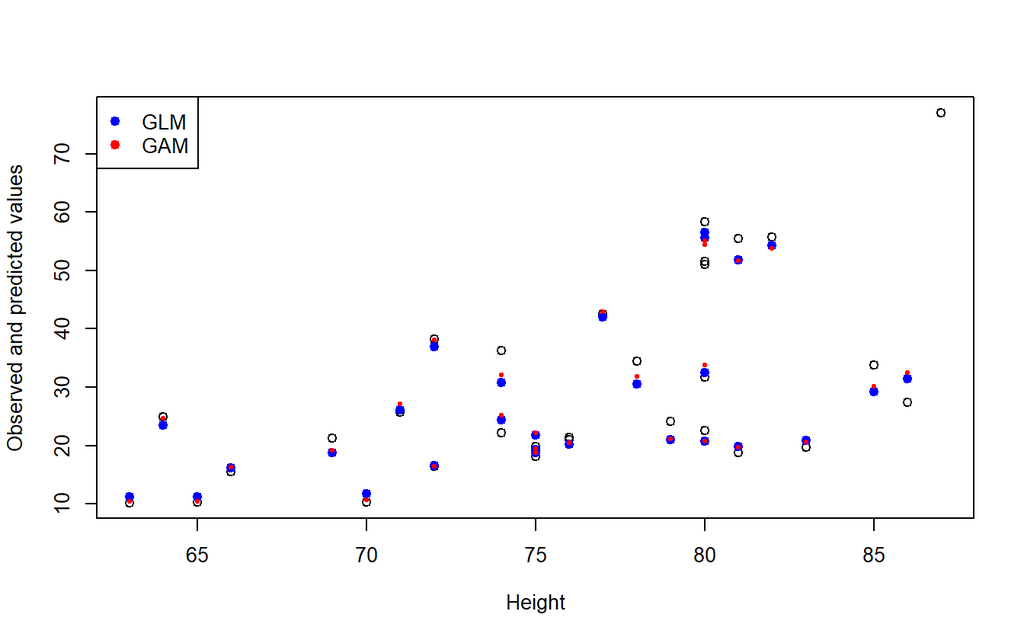

```r
# Plot the predicted values (w.r.t. the predictors) for both models
# Height
with(trees, plot(Height, Volume, xlab = "Height", ylab = "Observed and predicted values"))
points(trees$Height, glm.2$fitted.values, pch = 19, col = "blue")
points(trees$Height, gam.2$fitted.values, pch = 19, col = "red", cex=0.5)
legend("topleft", c("GLM", "GAM"), pch = 19, col = c("blue", "red"))
```

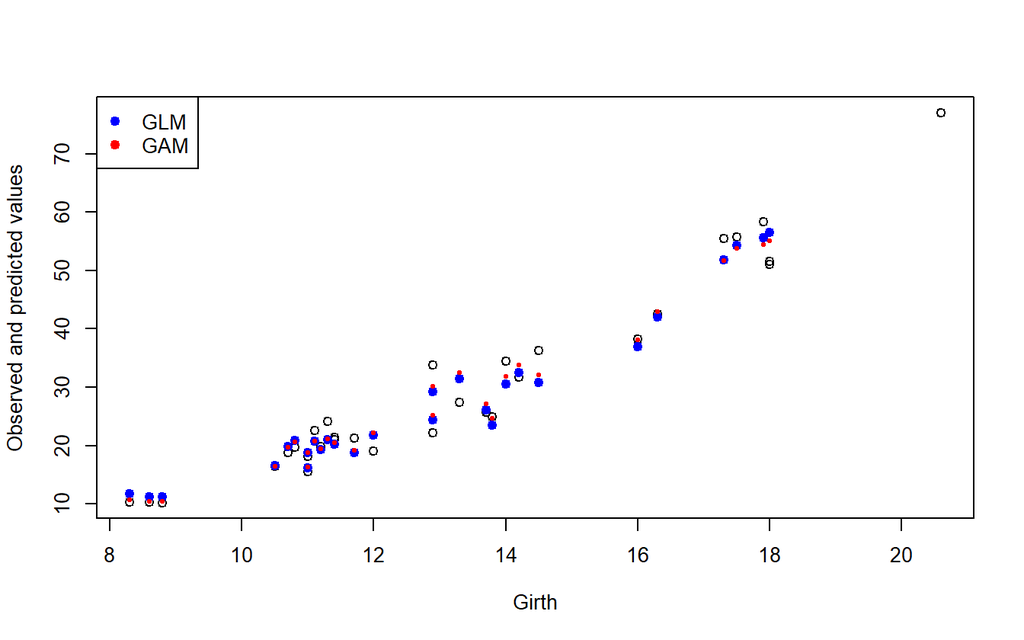

```r
# Girth
with(trees, plot(Girth, Volume, xlab = "Girth", ylab = "Observed and predicted values"))
points(trees$Girth, glm.2$fitted.values, pch = 19, col = "blue")
points(trees$Girth, gam.2$fitted.values, pch = 19, col = "red", cex=0.5)
legend("topleft", c("GLM", "GAM"), pch = 19, col = c("blue", "red"))
```

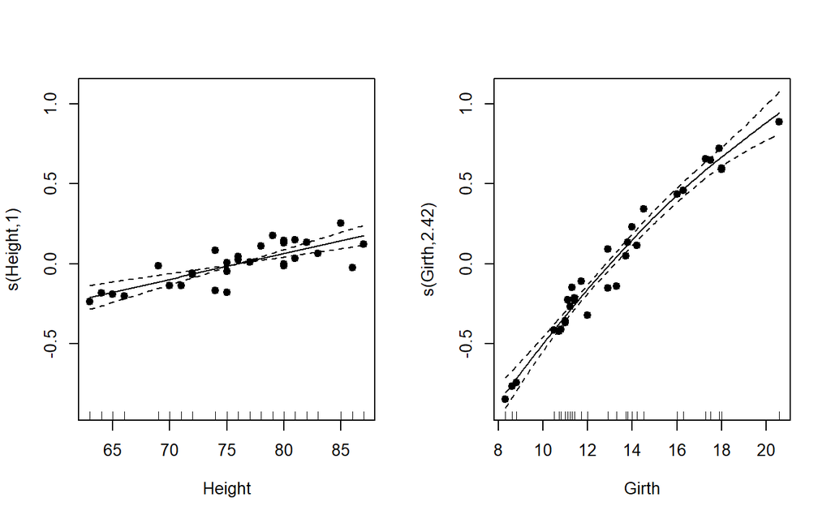

```r
# Diagnostic plot:
plot(gam.2, residuals = TRUE, pch = 19, pages = 1)
```

Options to visualize the fitted surface are collected in the function `vis.gam` which offers perspective and contour plot for a gam model.

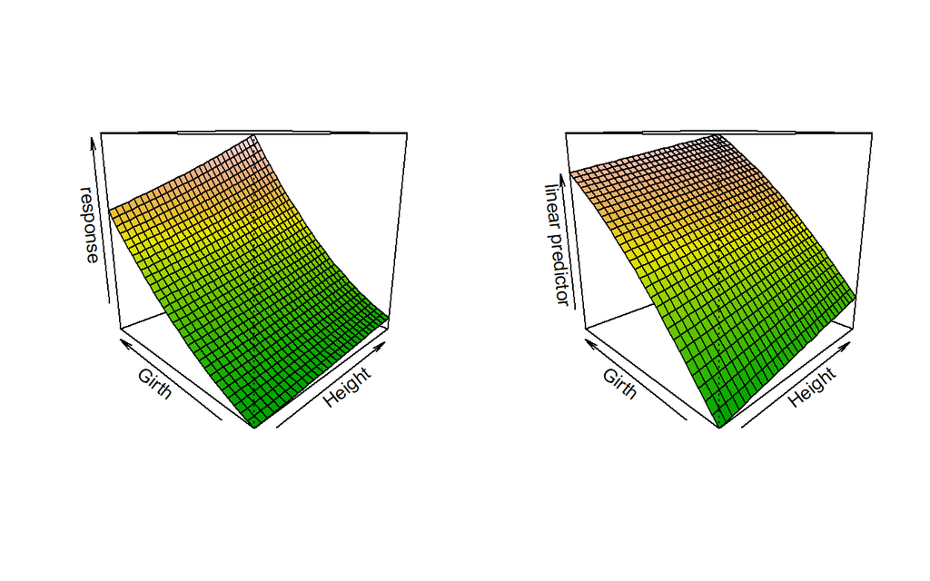

```r
# Fitted surface by using vis.gam() function
par(mfrow=c(1,2))
vis.gam(gam.2, theta = -45, color = "terrain", type = "response")
vis.gam(gam.2, theta = -45, color = "terrain", type = "link")
```

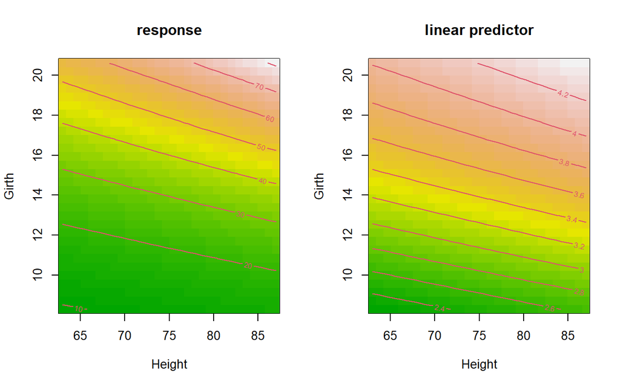

```r
# Contour plot by using vis.gam() function
par(mfrow=c(1,2))
vis.gam(gam.2, plot.type = "contour", color = "terrain", type = "response")
vis.gam(gam.2, plot.type = "contour", color = "terrain", type = "link")
```

```r
# Compare the fitted models by using AIC
AIC(glm.1, gam.1, glm.2, gam.2, gam.3)
```

```
##             df      AIC
## glm.1 3.000000 239.6724
## gam.1 3.000009 239.7580
## glm.2 4.000000 151.0081
## gam.2 5.422254 143.1907
## gam.3 5.422237 143.1907
```

The AIC dramatically decreases when considering the second predictor, with the GAM model favorite over the GLM model.

An issue we should consider is the so called **optimal degree of smoothness**. With the argument `sp` in the `gam` function we can manually control the degree of smoothness for each smooth function included in the model.

```r
# Fit the model setting the smoothing paramters to be 0s 8unpenalized regression spline)
gam.2.unp <- gam(Volume ~ s(Height, fx = TRUE) + s(Girth, fx = TRUE), data = trees,
             family = Gamma(link = "log"))
gam.2.unp$sp
```

```
## named numeric(0)
```

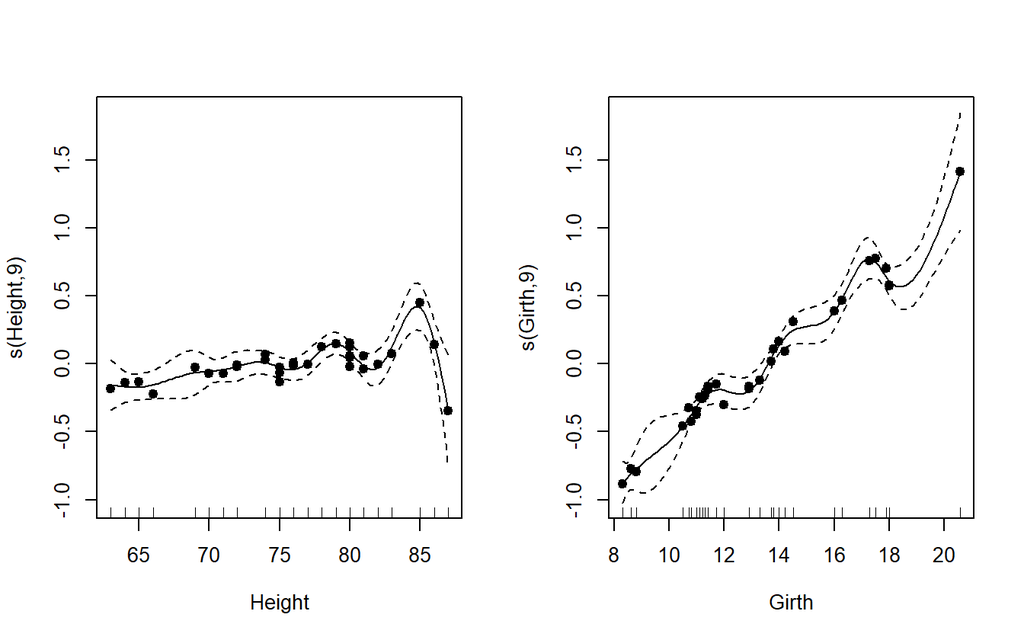

```r
# Alternatively
gam.2.unp <- gam(Volume ~ s(Height, sp = 0) + s(Girth, sp = 0), data = trees,
             family = Gamma(link = "log"))
# Diagnostic plot
plot(gam.2.unp, residuals = TRUE, pages = 1, pch = 19)
```

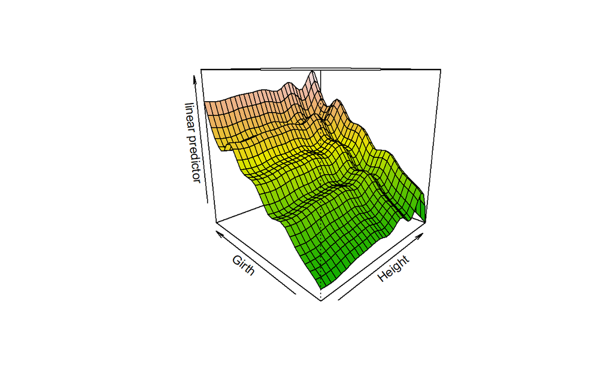

```r
# Fitted surface
par(mfrow=c(1,1))
vis.gam(gam.2.unp, theta = -45, type = "link", color  = "terrain")
```

However, usually $\lambda$ may be estimated by several methods, such as CV, AIC, BIC…By default, `gam` function estimates consider the method = “GCV.Cp” and scale = 0, meaning that the $\lambda$s are estimated via GCV, or via AIC if the family is Binomial or Poisson. Let’s take a look explicitly at how $\lambda$ is selected.

```r
# Look the smoothing parameter of gam.2
sp <- gam.2$sp
sp
```

```
##    s(Height)     s(Girth)
## 1.663969e+05 3.427109e-01
```

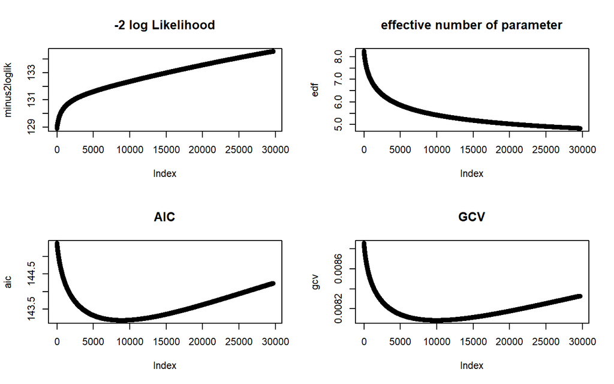

```r
# Let's look at the AIC/GCV and how the smoothing parameter is selected
# Consider a grid of value for (lambda1, lambda2) by analysing sp
lamb1 <- c(166396,166397,166398)
lamb2 <- seq(0.01,1, by = 0.0001)

sp.grid <- expand.grid(lamb1, lamb2 )
n.tuning <- nrow(sp.grid)


minus2loglik <- rep(NA, n.tuning)
edf <- rep(NA, n.tuning)
aic <- rep(NA, n.tuning)
gcv <- rep(NA, n.tuning)

for(i in 1:n.tuning){
 gamobj <- gam(Volume ~ s(Height) + s(Girth), data = trees,
             family = Gamma(link = "log"), sp = sp.grid[i,])
 minus2loglik[i] <- -2*logLik(gamobj)
 edf[i] <- sum(gamobj$edf) + 1
 aic[i] <- AIC(gamobj)
 gcv[i] <- gamobj$gcv.ubre
}

# Some Plots
par(mfrow=c(2,2))
plot(minus2loglik, type = "b", main = "-2 log Likelihood")
plot( edf, type = "b", main = "effective number of parameter")
plot( aic, type = "b", main = "AIC")
plot(gcv, type = "b", main = "GCV")
```

```r
# Find the minimum
opt.sp <- sp.grid[which.min(gcv),]
opt.sp
```

```
##        Var1   Var2
## 9984 166398 0.3427
```

```r
sp
```

```
##    s(Height)     s(Girth)
## 1.663969e+05 3.427109e-01
```

```r
gam.2.opt <- gam(Volume ~ s(Height) + s(Girth),
                 data = trees, family = Gamma(link = "log"), sp = opt.sp)
# Compare the AIC (gam.2 vs gam.2.opt)
AIC(gam.2, gam.2.opt)
```

```
##                 df      AIC
## gam.2     5.422254 143.1907
## gam.2.opt 5.422274 143.1907
```

**Exercise!**

1- Simulate some Poisson data with the `gamSim` function contained in the `mgcv` package (Use the default arguments `eg=1` for the Gu and Wahba 4 univariate term example and `scale=0.1`).

2- Fit a Gam and print the results. Interpret the fit.

3- Produce some plots for each $x_j$ plotted against $s(x_j)$, and comment. Do you maybe drop some covariates?

4- Compute the AIC between your final gam and a glm.

# Tree-based classification

We consider the example of detection of email spam. Data are available from the UCI repository of machine learning databases (http://www.ics.uci.edu/~mlearn/MLRepository.html) and they collect informations about 4601 email items, 1813 classified as spam. 57 explanatory variables describe several characteristics of the data. Following the example in the Data Analyisis and Graphics using R, we will consider only 6 of them, mostly related to the frequency of specific words and characters in the email. In detail,

- `crl.tot`: total length of words that are in capitals;
- `dollar`: the frequency of the $ symbol, as a percentage of all characters;
- `bang`: the frequency of the ! symbol, as a percentage of all characters;
- `money`: frequency of the word “money”, as a percentage of all words;
- `n000`: frequency of the character string “000”, as a percentage of all words;
- `make`: frequency of the word “make”, as a percentage of all words.

Using these 6 explanatory variables we want to build an decision tree model that is able to classify each email correctly as spam (`y` in the binary outcome variable `yesno`) and non-spam (`n` in the binary outcome variable `yesno`).

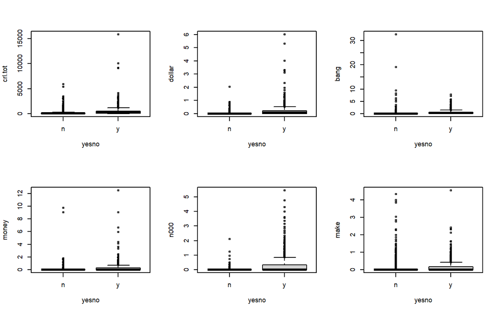

```r
library(reshape)
library(rpart)
library(rpart.plot)

# Load the dataset spambase
spam <-read.table("spambase.data", sep = ",")
# Take the columns
# 58: "yesno"
# 57: "crl.tot"
# 53: "dollar"
# 52: "bang"
# 24: "money"
# 23: "n000"
#  1: "make"
spam <- spam[, c(58,57,53,52,24,23,1)]

# Give the names to the columns
colnames(spam) <- c("yesno", "crl.tot", "dollar", "bang", "money", "n000", "make")

# Covert the yesno variable in a factor and assign "n" to 0 and "y" to 1
spam$yesno <- factor(spam$yesno, levels = c(0,1))
levels(spam$yesno) <- c("n","y")

# Produce the boxpolot
par(mfrow=c(2,3))
for(i in 2:7){
 boxplot(spam[,i] ~ yesno, data = spam, ylab=colnames(spam)[i])
}
```

```r
# Fit a glm
glm.spam <- glm(yesno ~ crl.tot + dollar + bang + money + n000 + make ,
                data = spam, family = binomial("logit") )
summary(glm.spam)
```

```
##
## Call:
## glm(formula = yesno ~ crl.tot + dollar + bang + money + n000 +
##     make, family = binomial("logit"), data = spam)
##
## Deviance Residuals:
##     Min       1Q   Median       3Q      Max
## -8.4904  -0.6153  -0.5816   0.4439   1.9323
##
## Coefficients:
##               Estimate Std. Error z value Pr(>|z|)
## (Intercept) -1.700e+00  5.361e-02 -31.717  < 2e-16 ***
## crl.tot      6.917e-04  9.745e-05   7.098 1.27e-12 ***
## dollar       8.013e+00  6.175e-01  12.976  < 2e-16 ***
## bang         1.572e+00  1.115e-01  14.096  < 2e-16 ***
## money        2.142e+00  2.418e-01   8.859  < 2e-16 ***
## n000         4.149e+00  4.371e-01   9.492  < 2e-16 ***
## make         1.698e-02  1.434e-01   0.118    0.906
## ---
## Signif. codes:  0 '***' 0.001 '**' 0.01 '*' 0.05 '.' 0.1 ' ' 1
##
## (Dispersion parameter for binomial family taken to be 1)
##
##     Null deviance: 6170.2  on 4600  degrees of freedom
## Residual deviance: 4058.8  on 4594  degrees of freedom
## AIC: 4072.8
##
## Number of Fisher Scoring iterations: 16
```

The model can be fitted using the function `rpart` in the library `rpart`. The option class in the method is selected by default when the outcome variable is of type factor.

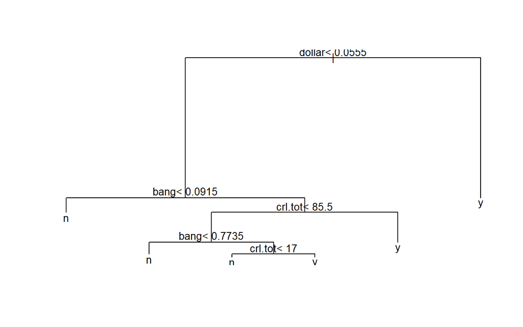

```r
# Consider a classification tree
spam.rpart <- rpart(yesno ~ crl.tot + dollar + bang + money + n000 + make ,
                    data = spam, method = "class")
# Plot the tree
par(mfrow=c(1,1))
plot(spam.rpart)
text(spam.rpart)
```

The summary of the fitted decision tree is visualized using the function `printcp`.

```r
# See the summary of the decision  tree
printcp(spam.rpart)
```

```
##
## Classification tree:
## rpart(formula = yesno ~ crl.tot + dollar + bang + money + n000 +
##     make, data = spam, method = "class")
##
## Variables actually used in tree construction:
## [1] bang    crl.tot dollar
##
## Root node error: 1813/4601 = 0.39404
##
## n= 4601
##
##         CP nsplit rel error  xerror     xstd
## 1 0.476558      0   1.00000 1.00000 0.018282
## 2 0.075565      1   0.52344 0.55323 0.015447
## 3 0.011583      3   0.37231 0.38279 0.013390
## 4 0.010480      4   0.36073 0.38224 0.013382
## 5 0.010000      5   0.35025 0.37562 0.013286
```

The complexity parameter `CP` is a proxy for the number of splits. In order to avoid too complex trees, the reduction of lack-of-fit for each additional split is evaluated with an increasing cost. When the cost outweights the reduction, the algorithm stops.

Small complexity parameter `CP` leads to large tree and large `CP`leads to small tree. Let’s try to decrease the default `CP` value for our model.

```r
# Fix cp = 0
spam.rpart.cp0 <- rpart(yesno ~ crl.tot + dollar + bang + money + n000 + make ,
                    data = spam, method = "class", cp=0)
# See the summary of the decision  tree
printcp(spam.rpart.cp0)
```

```
##
## Classification tree:
## rpart(formula = yesno ~ crl.tot + dollar + bang + money + n000 +
##     make, data = spam, method = "class", cp = 0)
##
## Variables actually used in tree construction:
## [1] bang    crl.tot dollar  make    money   n000
##
## Root node error: 1813/4601 = 0.39404
##
## n= 4601
##
##            CP nsplit rel error  xerror     xstd
## 1  4.7656e-01      0   1.00000 1.00000 0.018282
## 2  7.5565e-02      1   0.52344 0.54495 0.015363
## 3  1.1583e-02      3   0.37231 0.38720 0.013453
## 4  1.0480e-02      4   0.36073 0.38224 0.013382
## 5  6.3431e-03      5   0.35025 0.37452 0.013270
## 6  5.5157e-03     10   0.31660 0.36183 0.013081
## 7  4.4126e-03     11   0.31109 0.35687 0.013006
## 8  3.8610e-03     12   0.30667 0.35135 0.012921
## 9  2.7579e-03     16   0.29123 0.33480 0.012661
## 10 2.2063e-03     17   0.28847 0.33922 0.012732
## 11 1.9305e-03     18   0.28627 0.33811 0.012714
## 12 1.6547e-03     20   0.28240 0.33977 0.012740
## 13 9.1929e-04     25   0.27413 0.33260 0.012626
## 14 8.2736e-04     29   0.26917 0.33315 0.012635
## 15 5.5157e-04     46   0.25427 0.33646 0.012688
## 16 3.3094e-04     48   0.25317 0.34197 0.012775
## 17 2.7579e-04     53   0.25152 0.34418 0.012810
## 18 1.8386e-04     61   0.24931 0.34804 0.012870
## 19 6.8946e-05     64   0.24876 0.35080 0.012913
## 20 0.0000e+00     72   0.24821 0.35245 0.012938
```

The relative error showed in the summary decreases at any additional split, so it is not useful to evaluate the predictive accuracy of the model, while the xerror (which stands for cross-validated relative error) reaches a minimum. Since the xerror is computed using 10-fold cross-validation procedure by default, the values slightly changes everytime we fit a new model. The relative error remains exactly the same.

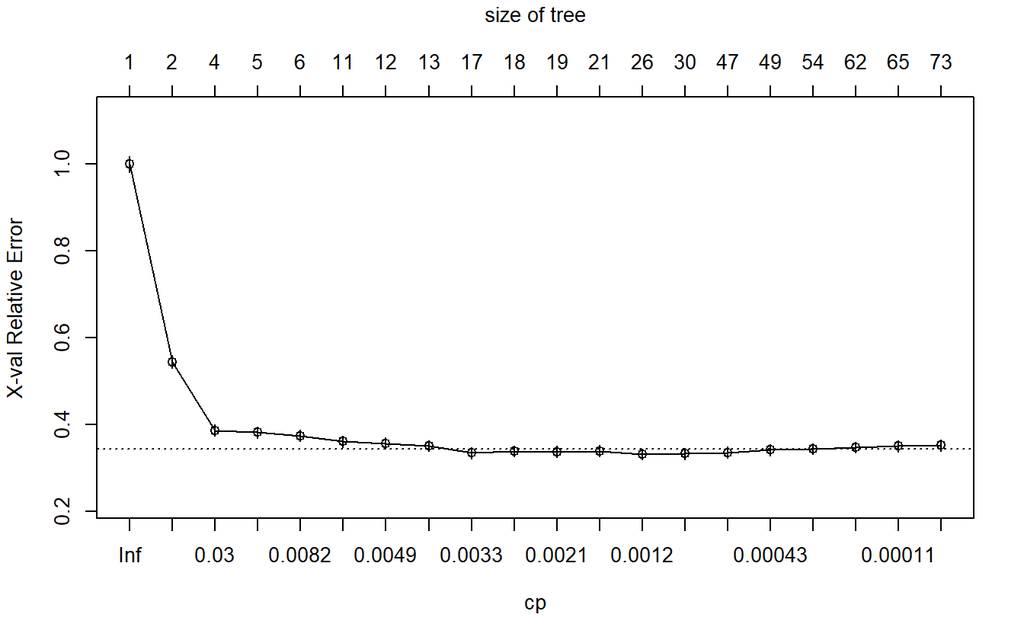

```r
# See the plot of the decision  tree
plotcp(spam.rpart.cp0)
```

Now that we have a very large (overfitted) tree, what is the best number of splits where to prune our tree? Changes in the xerrors are so small that running the model again would probably lead to a different choice of number of splits if it is based on selecting the tree with the absolute minimum xerror. To reduce instabilty in the choice we can use the one-standard-deviation rule. The horizontal dashed line in the plot shows the minimum xerror + standard deviation. So choosing the smallest tree whose xerror is less or equal than this value will lead us to a more conservative choice if the interest is in choosing the optimal predictive tree, i.e., the predictive power will on average be slightly less than optimal.

```r
# Select the best split
best.cp <- spam.rpart.cp0$cptable[which.min(spam.rpart.cp0$cptable[,"xerror"]),]
best.cp
```

```
##           CP       nsplit    rel error       xerror         xstd
## 9.192866e-04 2.500000e+01 2.741313e-01 3.325979e-01 1.262572e-02
```

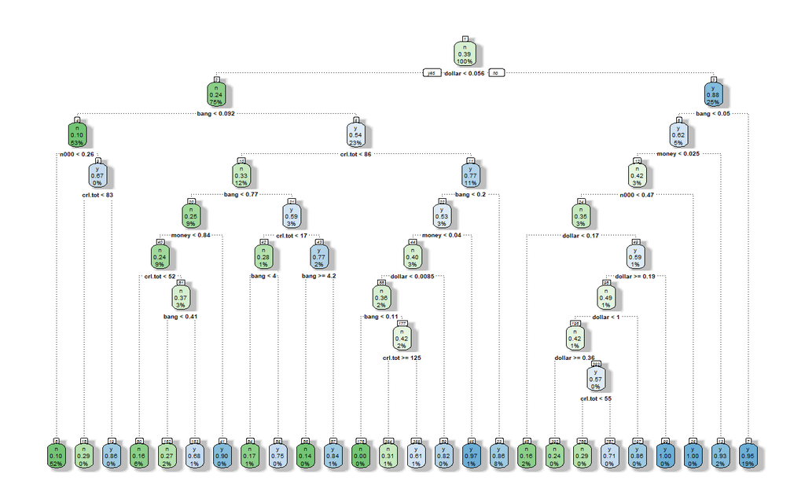

```r
# Select the best split according to standard deviation rule
sd.rule<- best.cp["xerror"] + best.cp["xstd"]
cptable.sd.rule <- spam.rpart.cp0$cptable[spam.rpart.cp0$cptable[,"xerror"]<=sd.rule,]
best.cp.sd <- cptable.sd.rule[which.min(cptable.sd.rule[,"nsplit"]),]


# Plot the pruned tree
# According to best.cp
tree.pruned <-prune(spam.rpart.cp0, cp=best.cp[1])
rpart.plot(tree.pruned, extra=106,box.palette="GnBu", branch.lty = 3,
           shadow.col = "gray", nn=TRUE)
```

```r
printcp(tree.pruned)
```

```
##
## Classification tree:
## rpart(formula = yesno ~ crl.tot + dollar + bang + money + n000 +
##     make, data = spam, method = "class", cp = 0)
##
## Variables actually used in tree construction:
## [1] bang    crl.tot dollar  money   n000
##
## Root node error: 1813/4601 = 0.39404
##
## n= 4601
##
##            CP nsplit rel error  xerror     xstd
## 1  0.47655819      0   1.00000 1.00000 0.018282
## 2  0.07556536      1   0.52344 0.54495 0.015363
## 3  0.01158301      3   0.37231 0.38720 0.013453
## 4  0.01047987      4   0.36073 0.38224 0.013382
## 5  0.00634308      5   0.35025 0.37452 0.013270
## 6  0.00551572     10   0.31660 0.36183 0.013081
## 7  0.00441258     11   0.31109 0.35687 0.013006
## 8  0.00386100     12   0.30667 0.35135 0.012921
## 9  0.00275786     16   0.29123 0.33480 0.012661
## 10 0.00220629     17   0.28847 0.33922 0.012732
## 11 0.00193050     18   0.28627 0.33811 0.012714
## 12 0.00165472     20   0.28240 0.33977 0.012740
## 13 0.00091929     25   0.27413 0.33260 0.012626
```

```r
# According to the standard deviation rule
tree.pruned.sd <-prune(spam.rpart.cp0, cp=best.cp.sd[1])
printcp(tree.pruned.sd)
```

```
##
## Classification tree:
## rpart(formula = yesno ~ crl.tot + dollar + bang + money + n000 +
##     make, data = spam, method = "class", cp = 0)
##
## Variables actually used in tree construction:
## [1] bang    crl.tot dollar  money   n000
##
## Root node error: 1813/4601 = 0.39404
##
## n= 4601
##
##          CP nsplit rel error  xerror     xstd
## 1 0.4765582      0   1.00000 1.00000 0.018282
## 2 0.0755654      1   0.52344 0.54495 0.015363
## 3 0.0115830      3   0.37231 0.38720 0.013453
## 4 0.0104799      4   0.36073 0.38224 0.013382
## 5 0.0063431      5   0.35025 0.37452 0.013270
## 6 0.0055157     10   0.31660 0.36183 0.013081
## 7 0.0044126     11   0.31109 0.35687 0.013006
## 8 0.0038610     12   0.30667 0.35135 0.012921
## 9 0.0027579     16   0.29123 0.33480 0.012661
```

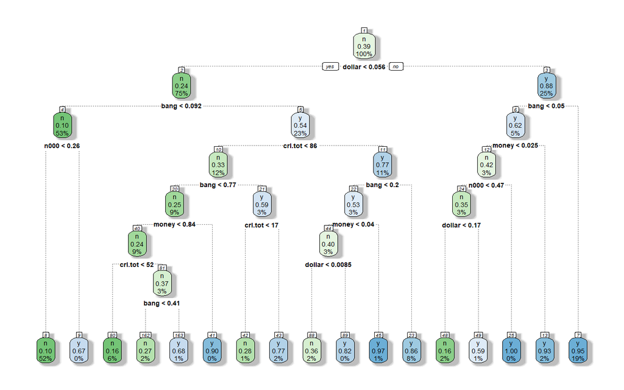

```r
rpart.plot(tree.pruned.sd, extra=106,box.palette="GnBu", branch.lty = 3,
           shadow.col = "gray", nn=TRUE)
```

Absolute cross validation error for this last model is: $0.33756*0.39404=0.1330121$, thus the model achieved an error rate of 13.3%. (The value of 0.33756 could be different since it depends on the CV)

**Exercise** Explore the RandomForest

```r
library(randomForest)

spam.rf <- randomForest(yesno ~ ., data = spam, importance =TRUE)
print(spam.rf)
```

```
##
## Call:
##  randomForest(formula = yesno ~ ., data = spam, importance = TRUE)
##                Type of random forest: classification
##                      Number of trees: 500
## No. of variables tried at each split: 2
##
##         OOB estimate of  error rate: 11.95%
## Confusion matrix:
##      n    y class.error
## n 2646  142  0.05093257
## y  408 1405  0.22504137
```

```r
importance(spam.rf)
```

```
##                n        y MeanDecreaseAccuracy MeanDecreaseGini
## crl.tot 50.77235 55.33954             73.34004        242.30521
## dollar  55.79124 54.93206             75.52549        433.39394
## bang    95.59606 94.61661            113.70911        577.15248
## money   31.28266 46.39277             52.12303        206.58187
## n000    57.58648 14.83179             60.69403        125.13205
## make    12.57474 22.46849             26.54964         42.20843
```

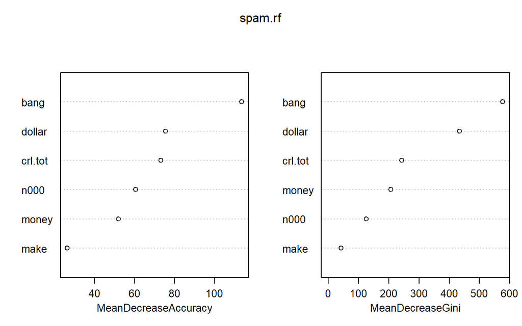

```r
varImpPlot(spam.rf, sort=TRUE)
```